# Análisis de espacial-Productos subutilizados

## Tratamiento de los datos

```r
distritos <- st_read("C:/Users/User/Documents/Mayker/Promidata/Curso de Visualizacion de datos/2-Clase/geo_data/distritos/distritos.shp")
distritos <- st_transform(distritos, crs = "+proj=longlat +ellps=WGS84 +no_defs")
```

## Distribución de los distritos por porcentanje de vendedores de productos subutilizados

En este caso, el distrito toma el valor de uno si todos sus vendedores ofrecen productos subutilizados y en caso opuesto, toma el valor de cero, cuando ninguno de sus vendedores ofrece productos subutilizados.

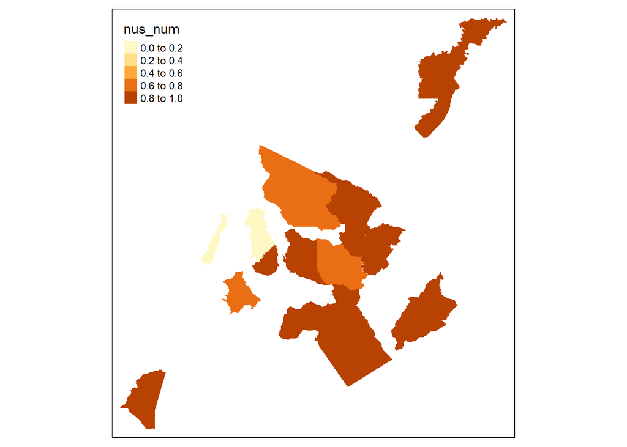

```r
tm_shape(data_comple1)+ tm_fill(col = "nus_num")
```

## Cálculo de la correlación de I de moran -Porcenje de vendedores de productos subtulizados por distrito

Cálculo para el porcentaje de vendedores que ofrecen productos subutilizados en relación al total de vendedores del distrito.

Para obtener la correlación de I de moran se debe calcular la matriz de vecinos, pero esta matriz solo se puede construir cuando los distritos son adyacentes entre sí, por esta razón se procede con la eliminación de los distritos que no están unificados.

**Esto se hace mediante el siguiente código:**

```r
data_comple=data_comple1 %>% filter(##dist_nom2=='Cervantes' |
                          dist_nom2=='Juan Viñas' |
                          dist_nom2=='La Isabel' |
                          ##dist_nom2=='Pacayas' |
                          ##dist_nom2=='Paraíso' |
                          dist_nom2=='Pavones' |
                          dist_nom2=='Pejibaye' |
                          ##dist_nom2=='San Marcos' |
                          dist_nom2=='Santa Cruz' |
                          dist_nom2=='Santa Teresita' |
                          ##dist_nom2=='Tayutic' |
                          ##dist_nom2=='Tierra Blanca' |
                          dist_nom2=='Turrialba')
```

**Gráfico con los distritos adyacentes**

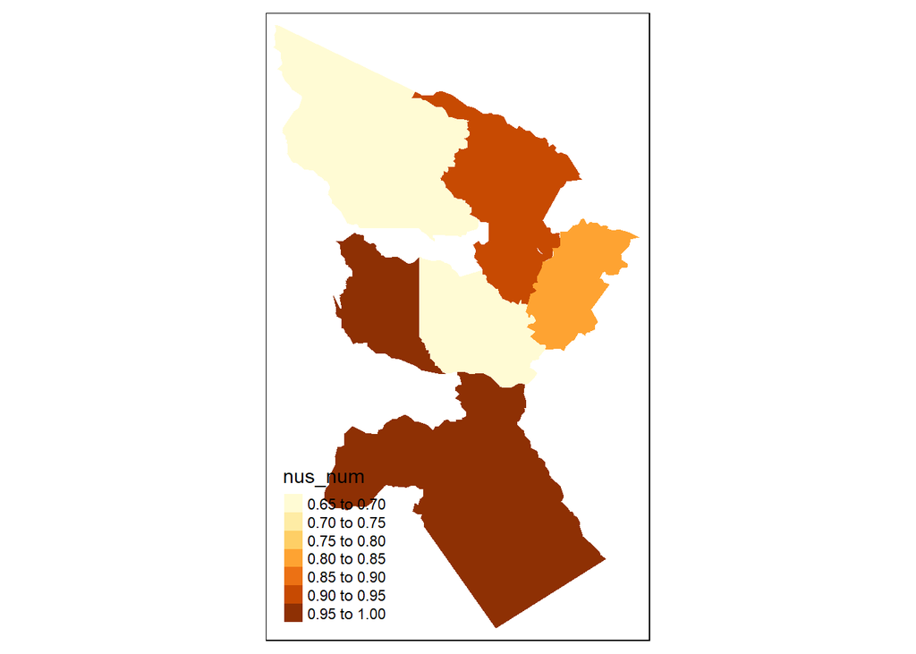

```r
tm_shape(data_comple)+ tm_fill(col = "nus_num")
```

**Cálculo de los vecinos**

```r
data_comple$value=data_comple$nus_num


w <- poly2nb(data_comple, row.names=data_comple$dist_id)

class(w)
```

```
## [1] "nb"
```

```r
summary(w)
```

```
## Neighbour list object:
## Number of regions: 7
## Number of nonzero links: 16
## Percentage nonzero weights: 32.65306
## Average number of links: 2.285714
## Link number distribution:
##
## 1 3 4
## 3 3 1
## 3 least connected regions:
## 1 3 7 with 1 link
## 1 most connected region:
## 2 with 4 links
```

```r
ww <-  nb2listw(w, style='B')
ww
```

```
## Characteristics of weights list object:
## Neighbour list object:
## Number of regions: 7
## Number of nonzero links: 16
## Percentage nonzero weights: 32.65306
## Average number of links: 2.285714
##
## Weights style: B
## Weights constants summary:
##   n nn S0 S1  S2
## B 7 49 16 32 184
```

**En el siguiente apartado se hace el calculo de la I de moran**

Cálculo con *moran.test*

```r
moran.test(data_comple$value, ww, randomisation=FALSE)
```

```
##
##  Moran I test under normality
##
## data:  data_comple$value
## weights: ww
##
## Moran I statistic standard deviate = -1.5499, p-value = 0.9394
## alternative hypothesis: greater
## sample estimates:
## Moran I statistic       Expectation          Variance
##       -0.53835329       -0.16666667        0.05750868
```

Cálculo con *moran.mc*

```r
moran.mc(data_comple$value, ww, nsim = 200)
```

```
##
##  Monte-Carlo simulation of Moran I
##
## data:  data_comple$value
## weights: ww
## number of simulations + 1: 201
##
## statistic = -0.53835, observed rank = 9, p-value = 0.9552
## alternative hypothesis: greater
```

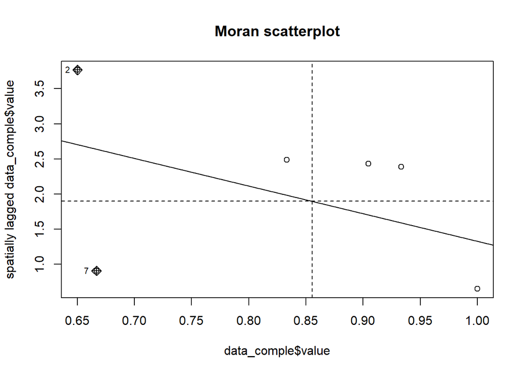

```r
 moran.plot(data_comple$value, listw=ww, quiet=TRUE)
title("Moran scatterplot")
```

*En general, en ambos casos, con un nivel de significacia del 5% no se rechaza la hipotesis nula de independencia espacial en el porcentaje de vendedores que ofrecen productos subutilizados por distrito*

## Cálculo del test de correlación ponderada con la población

Cuando se tienen poblaciones muy desiguales entre áreas, es mejor utilizar EBI Moran y precisamente en ese caso tenemos distritos con muchos vendedores en relación al total y otros con pocos.

```r
EBImoran.mc(n=data_comple$value, x=data_comple$q, listw=ww, nsim=999)
```

```
## The default for subtract_mean_in_numerator set TRUE from February 2016
```

```
##
##  Monte-Carlo simulation of Empirical Bayes Index (mean subtracted)
##
## data:  cases: data_comple$value, risk population: data_comple$q
## weights: ww
## number of simulations + 1: 1000
##
## statistic = -0.1041, observed rank = 618, p-value = 0.382
## alternative hypothesis: greater
```

## Cálculo de la correlación de I de moran -cantidad promedio de productos subutilizados

```r
data_comple$value=data_comple$cantidad_nus


w <- poly2nb(data_comple, row.names=data_comple$dist_id)

class(w)
```

```
## [1] "nb"
```

```r
summary(w)
```

```
## Neighbour list object:
## Number of regions: 7
## Number of nonzero links: 16
## Percentage nonzero weights: 32.65306
## Average number of links: 2.285714
## Link number distribution:
##
## 1 3 4
## 3 3 1
## 3 least connected regions:
## 1 3 7 with 1 link
## 1 most connected region:
## 2 with 4 links
```

```r
ww <-  nb2listw(w, style='B')
ww
```

```
## Characteristics of weights list object:
## Neighbour list object:
## Number of regions: 7
## Number of nonzero links: 16
## Percentage nonzero weights: 32.65306
## Average number of links: 2.285714
##
## Weights style: B
## Weights constants summary:
##   n nn S0 S1  S2
## B 7 49 16 32 184
```

Cálculo con *moran.test*

```r
moran.test(data_comple$value, ww, randomisation=FALSE)
```

```
##
##  Moran I test under normality
##
## data:  data_comple$value
## weights: ww
##
## Moran I statistic standard deviate = -0.10932, p-value = 0.5435
## alternative hypothesis: greater
## sample estimates:
## Moran I statistic       Expectation          Variance
##       -0.19288358       -0.16666667        0.05750868
```

Cálculo con *moran.mc*

```r
moran.mc(data_comple$value, ww, nsim = 200)
```

```
##
##  Monte-Carlo simulation of Moran I
##
## data:  data_comple$value
## weights: ww
## number of simulations + 1: 201
##
## statistic = -0.19288, observed rank = 82, p-value = 0.592
## alternative hypothesis: greater
```

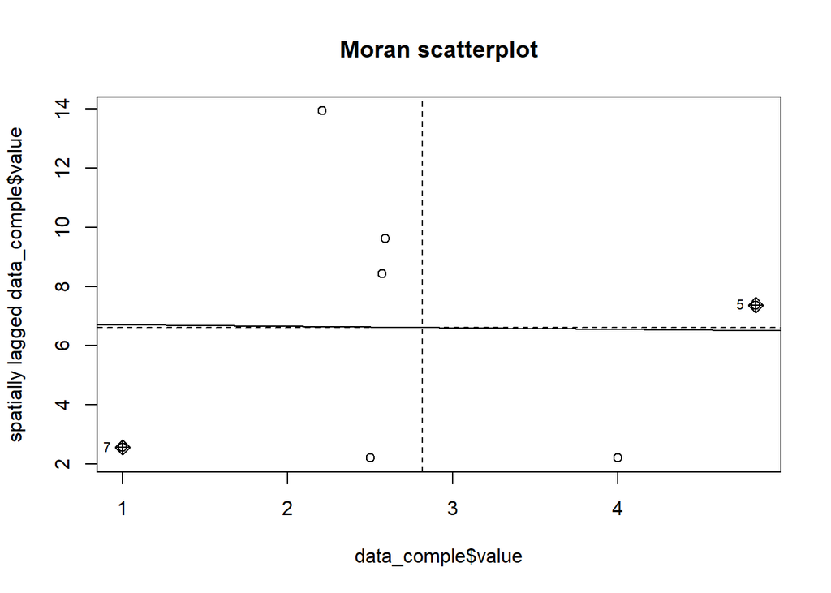

```r
 moran.plot(data_comple$value, listw=ww, quiet=TRUE)
title("Moran scatterplot")
```

## Cálculo del test de correlación ponderada con la población

Cuando se tienen poblaciones muy desiguales entre áreas, es mejor utilizar EBI Moran y precisamente en ese caso tenemos distritos con muchos vendedores en relación al total y otros con pocos.

```r
EBImoran.mc(n=data_comple$value, x=data_comple$q, listw=ww, nsim=999)
```

```
## The default for subtract_mean_in_numerator set TRUE from February 2016
```

```
##
##  Monte-Carlo simulation of Empirical Bayes Index (mean subtracted)
##
## data:  cases: data_comple$value, risk population: data_comple$q
## weights: ww
## number of simulations + 1: 1000
##
## statistic = -0.070568, observed rank = 626, p-value = 0.374
## alternative hypothesis: greater
```

## Cálculo de correlación por cantón

En el cálculo anterior se realizó el cálculo de la correlación pero por distrito, ahora se va hacer por cantón

```r
cantones <- st_read("C:/Users/User/Documents/Mayker/Promidata/Curso de Visualizacion de datos/2-Clase/geo_data/cantones/cantones.shp")
cantones <- st_transform(cantones, crs = "+proj=longlat +ellps=WGS84 +no_defs")
```

Se agrupa la información de vendedores por cantón

```r
vendedores_canton=data1 %>% group_by(canton) %>%
                            summarise(nus_num= mean(nus_num),
                            cantidad_nus=mean(cantidad_nus),
                            q=sum(cantador))
data_comple_canton <- left_join(x = cantones,
                        y = vendedores_canton,
                        by = c("cant_nom2" = "canton"))
```

## Gráfico de los cantones según porcentaje de vendedores de productos subutilizados

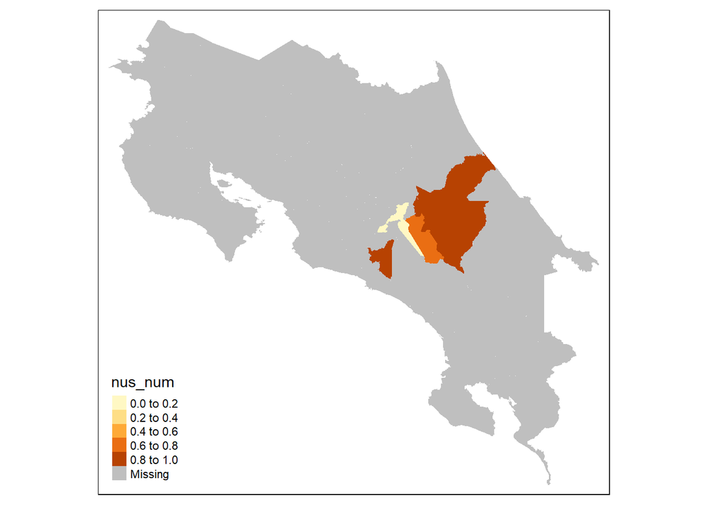

```r
tm_shape(data_comple_canton)+ tm_fill(col = "nus_num")
```

## Gráfico de los cantones según porcentaje de vendedores de productos subutilizados

Se filtran solo aquellos cantones que tienen información

```r
data_comple_canton_filtro=data_comple_canton %>% filter(is.na(cantidad_nus)==FALSE)
```

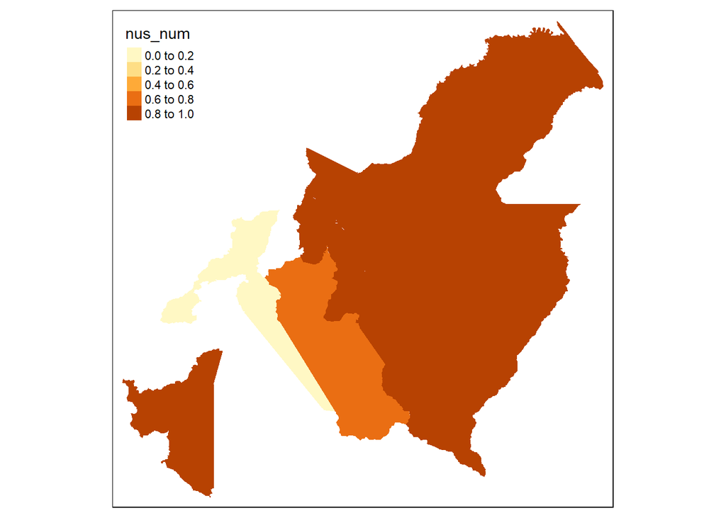

```r
tm_shape(data_comple_canton_filtro)+ tm_fill(col = "nus_num")
```

En caso el cantón de Tarrazú es un cantón que no está adyacende de los demás, por lo tanto se elimina para realizar el cálculo de la I de moran.

```r
data_comple_canton_filtro=data_comple_canton_filtro %>% filter(!cant_nom2=='Tarrazú')
```

## Gráfico de los cantones según porcentaje de vendedores de productos subutilizados

Sin el cantón de Tarrazú

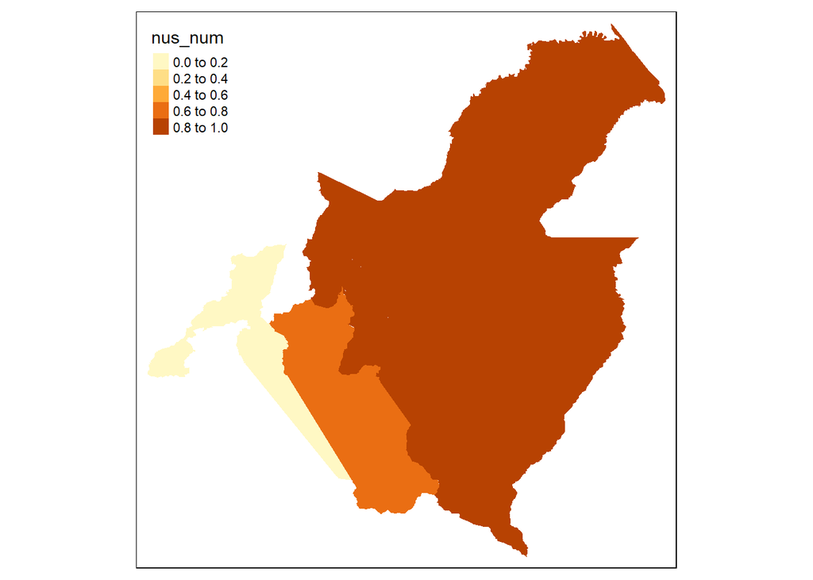

```r
tm_shape(data_comple_canton_filtro)+ tm_fill(col = "nus_num")
```

## Calculo de la correlacion espacial

Porcentaje de vendedores de productos subutilizados por cantón

```r
data_comple_canton_filtro$value=data_comple_canton_filtro$nus_num



w <- poly2nb(data_comple_canton_filtro, row.names=data_comple_canton_filtro$cant_id)

class(w)
```

```
## [1] "nb"
```

```r
summary(w)
```

```
## Neighbour list object:
## Number of regions: 6
## Number of nonzero links: 16
## Percentage nonzero weights: 44.44444
## Average number of links: 2.666667
## Link number distribution:
##
## 1 3 4
## 2 2 2
## 2 least connected regions:
## 1 6 with 1 link
## 2 most connected regions:
## 2 4 with 4 links
```

```r
ww <-  nb2listw(w, style='B')
ww
```

```
## Characteristics of weights list object:
## Neighbour list object:
## Number of regions: 6
## Number of nonzero links: 16
## Percentage nonzero weights: 44.44444
## Average number of links: 2.666667
##
## Weights style: B
## Weights constants summary:
##   n nn S0 S1  S2
## B 6 36 16 32 208
```

Cálculo con *moran.test*

```r
moran.test(data_comple_canton_filtro$value, ww, randomisation=FALSE)
```

```
##
##  Moran I test under normality
##
## data:  data_comple_canton_filtro$value
## weights: ww
##
## Moran I statistic standard deviate = 1.4852, p-value = 0.06875
## alternative hypothesis: greater
## sample estimates:
## Moran I statistic       Expectation          Variance
##        0.07785123       -0.20000000        0.03500000
```

Cálculo con *moran.mc*

```r
moran.mc(data_comple_canton_filtro$value, ww, nsim = 300)
```

```
##
##  Monte-Carlo simulation of Moran I
##
## data:  data_comple_canton_filtro$value
## weights: ww
## number of simulations + 1: 301
##
## statistic = 0.077851, observed rank = 261.5, p-value = 0.1312
## alternative hypothesis: greater
```

*En general, en ambos casos con un nivel de significacia del 5% no se rechaza la hipotesis nula de independencia espacial en el porcentaje de productos subutilizados por cantón*

## Cálculo del test de correlación ponderada con la población

Cuando se tienen poblaciones muy desiguales entre áreas, es mejor utilizar EBI Moran y precisamente en ese caso tenemos cantones con muchos vendedores en relación al total y otros con pocos.

```r
EBImoran.mc(n=data_comple_canton_filtro$value, x=data_comple_canton_filtro$q, listw=ww, nsim=400)
```

```
## The default for subtract_mean_in_numerator set TRUE from February 2016
```

```
##
##  Monte-Carlo simulation of Empirical Bayes Index (mean subtracted)
##
## data:  cases: data_comple_canton_filtro$value, risk population: data_comple_canton_filtro$q
## weights: ww
## number of simulations + 1: 401
##
## statistic = -0.56751, observed rank = 4.5, p-value = 0.9888
## alternative hypothesis: greater
```

Con un nivel de significancia del 5% no se rechaza la hipótesis nula de independencia espacial

## Correlación espacial de la cantidad de productos subutilizados

Se obtiene la cantidad promedio de productos subutilizados vendidos por vendedores de cada cantón

```r
data_comple_canton_filtro$value=data_comple_canton_filtro$cantidad_nus


w <- poly2nb(data_comple_canton_filtro, row.names=data_comple_canton_filtro$cant_id)

class(w)
```

```
## [1] "nb"
```

```r
summary(w)
```

```
## Neighbour list object:
## Number of regions: 6
## Number of nonzero links: 16
## Percentage nonzero weights: 44.44444
## Average number of links: 2.666667
## Link number distribution:
##
## 1 3 4
## 2 2 2
## 2 least connected regions:
## 1 6 with 1 link
## 2 most connected regions:
## 2 4 with 4 links
```

```r
ww <-  nb2listw(w, style='B')
ww
```

```
## Characteristics of weights list object:
## Neighbour list object:
## Number of regions: 6
## Number of nonzero links: 16
## Percentage nonzero weights: 44.44444
## Average number of links: 2.666667
##
## Weights style: B
## Weights constants summary:
##   n nn S0 S1  S2
## B 6 36 16 32 208
```

Cálculo con *moran.test*

```r
moran.test(data_comple_canton_filtro$value, ww, randomisation=FALSE)
```

```
##
##  Moran I test under normality
##
## data:  data_comple_canton_filtro$value
## weights: ww
##
## Moran I statistic standard deviate = 1.6208, p-value = 0.05253
## alternative hypothesis: greater
## sample estimates:
## Moran I statistic       Expectation          Variance
##         0.1032323        -0.2000000         0.0350000
```

Cálculo con *moran.mc*

```r
moran.mc(data_comple_canton_filtro$value, ww, nsim = 400)
```

```
##
##  Monte-Carlo simulation of Moran I
##
## data:  data_comple_canton_filtro$value
## weights: ww
## number of simulations + 1: 401
##
## statistic = 0.10323, observed rank = 383, p-value = 0.04489
## alternative hypothesis: greater
```

## Cálculo del test de correlación ponderada con la población

Cuando se tienen poblaciones muy desiguales entre áreas, es mejor utilizar EBI Moran y precisamente en ese caso tenemos cantones con muchos vendedores en relación al total y otros con pocos.

```r
EBImoran.mc(n=data_comple_canton_filtro$value, x=data_comple_canton_filtro$q, listw=ww, nsim=400)
```

```
## The default for subtract_mean_in_numerator set TRUE from February 2016
```

```
##
##  Monte-Carlo simulation of Empirical Bayes Index (mean subtracted)
##
## data:  cases: data_comple_canton_filtro$value, risk population: data_comple_canton_filtro$q
## weights: ww
## number of simulations + 1: 401
##
## statistic = -0.22657, observed rank = 192, p-value = 0.5212
## alternative hypothesis: greater
```

En este caso, al hacer la ponderación con la población no se rechaza la hipotesis nula de independecia espacial en la cantidad promedio vedida de vendedores por cantón